# Lab 3 - Linear Regression

We will revisit the full Toyota Corolla data as an illustrative example in this lab to learn basic linear regression and analysis with R. The code in this lab is not the only correct way to do things. However, it is important for you to understand what each statement does. Mostly, only the basic commands are introduced, but you are encouraged to explore the details using R’s help features.

# Load Data

```r
toyota <- read.csv("ToyotaCorolla.csv")
```

# EDA

We have already performed some EDA on the Toyota Corolla data. We will briefly go through some of them here.

```r
dim(toyota)
```

```
## [1] 1436   39
```

```r
names(toyota)
```

```
##  [1] "Id"                "Model"             "Price"
##  [4] "Age_08_04"         "Mfg_Month"         "Mfg_Year"
##  [7] "KM"                "Fuel_Type"         "HP"
## [10] "Met_Color"         "Color"             "Automatic"
## [13] "CC"                "Doors"             "Cylinders"
## [16] "Gears"             "Quarterly_Tax"     "Weight"
## [19] "Mfr_Guarantee"     "BOVAG_Guarantee"   "Guarantee_Period"
## [22] "ABS"               "Airbag_1"          "Airbag_2"
## [25] "Airco"             "Automatic_airco"   "Boardcomputer"
## [28] "CD_Player"         "Central_Lock"      "Powered_Windows"
## [31] "Power_Steering"    "Radio"             "Mistlamps"
## [34] "Sport_Model"       "Backseat_Divider"  "Metallic_Rim"
## [37] "Radio_cassette"    "Parking_Assistant" "Tow_Bar"
```

```r
str(toyota)
```

```
## 'data.frame':    1436 obs. of  39 variables:
##  $ Id               : int  1 2 3 4 5 6 7 8 9 10 ...
##  $ Model            : Factor w/ 372 levels " TOYOTA Corolla 1.3 16V HATCHB G6 2/3-Doors",..: 332 332 67 332 331 331 64 326 62 59 ...
##  $ Price            : int  13500 13750 13950 14950 13750 12950 16900 18600 21500 12950 ...
##  $ Age_08_04        : int  23 23 24 26 30 32 27 30 27 23 ...
##  $ Mfg_Month        : int  10 10 9 7 3 1 6 3 6 10 ...
##  $ Mfg_Year         : int  2002 2002 2002 2002 2002 2002 2002 2002 2002 2002 ...
##  $ KM               : int  46986 72937 41711 48000 38500 61000 94612 75889 19700 71138 ...
##  $ Fuel_Type        : Factor w/ 3 levels "CNG","Diesel",..: 2 2 2 2 2 2 2 2 3 2 ...
##  $ HP               : int  90 90 90 90 90 90 90 90 192 69 ...
##  $ Met_Color        : int  1 1 1 0 0 0 1 1 0 0 ...
##  $ Color            : Factor w/ 10 levels "Beige","Black",..: 3 7 3 2 2 9 5 5 6 3 ...
##  $ Automatic        : int  0 0 0 0 0 0 0 0 0 0 ...
##  $ CC               : int  2000 2000 2000 2000 2000 2000 2000 2000 1800 1900 ...
##  $ Doors            : int  3 3 3 3 3 3 3 3 3 3 ...
```

[output cut: 25 more lines]

```r
summary(toyota)
```

```
##        Id
##  Min.   :   1.0
##  1st Qu.: 361.8
##  Median : 721.5
##  Mean   : 721.6
##  3rd Qu.:1081.2
##  Max.   :1442.0
##
##                                                  Model
##  TOYOTA Corolla 1.6 16V HATCHB LINEA TERRA 2/3-Doors: 107
##  TOYOTA Corolla 1.3 16V HATCHB LINEA TERRA 2/3-Doors:  83
##  TOYOTA Corolla 1.6 16V LIFTB LINEA LUNA 4/5-Doors  :  79
##  TOYOTA Corolla 1.6 16V LIFTB LINEA TERRA 4/5-Doors :  70
##  TOYOTA Corolla 1.6 16V SEDAN LINEA TERRA 4/5-Doors :  43
##  TOYOTA Corolla 1.4 16V VVT I HATCHB TERRA 2/3-Doors:  42
##  (Other)                                            :1012
##      Price         Age_08_04       Mfg_Month         Mfg_Year
##  Min.   : 4350   Min.   : 1.00   Min.   : 1.000   Min.   :1998
##  1st Qu.: 8450   1st Qu.:44.00   1st Qu.: 3.000   1st Qu.:1998
##  Median : 9900   Median :61.00   Median : 5.000   Median :1999
##  Mean   :10731   Mean   :55.95   Mean   : 5.549   Mean   :2000
##  3rd Qu.:11950   3rd Qu.:70.00   3rd Qu.: 8.000   3rd Qu.:2001
##  Max.   :32500   Max.   :80.00   Max.   :12.000   Max.   :2004
##
##        KM          Fuel_Type          HP          Met_Color
##  Min.   :     1   CNG   :  17   Min.   : 69.0   Min.   :0.0000
##  1st Qu.: 43000   Diesel: 155   1st Qu.: 90.0   1st Qu.:0.0000
##  Median : 63390   Petrol:1264   Median :110.0   Median :1.0000
##  Mean   : 68533                 Mean   :101.5   Mean   :0.6748
##  3rd Qu.: 87021                 3rd Qu.:110.0   3rd Qu.:1.0000
##  Max.   :243000                 Max.   :192.0   Max.   :1.0000
##
##      Color       Automatic             CC            Doors
##  Grey   :301   Min.   :0.00000   Min.   : 1300   Min.   :2.000
##  Blue   :283   1st Qu.:0.00000   1st Qu.: 1400   1st Qu.:3.000
##  Red    :278   Median :0.00000   Median : 1600   Median :4.000
##  Green  :220   Mean   :0.05571   Mean   : 1577   Mean   :4.033
##  Black  :191   3rd Qu.:0.00000   3rd Qu.: 1600   3rd Qu.:5.000
##  Silver :122   Max.   :1.00000   Max.   :16000   Max.   :5.000
##  (Other): 41
```

[output cut: 41 more lines]

```
##  Min.   :0.0000   Min.   :0.0000   Min.   :0.0000   Min.   :0.000000
##  1st Qu.:1.0000   1st Qu.:0.0000   1st Qu.:0.0000   1st Qu.:0.000000
##  Median :1.0000   Median :0.0000   Median :0.0000   Median :0.000000
##  Mean   :0.7702   Mean   :0.2047   Mean   :0.1455   Mean   :0.002786
##  3rd Qu.:1.0000   3rd Qu.:0.0000   3rd Qu.:0.0000   3rd Qu.:0.000000
##  Max.   :1.0000   Max.   :1.0000   Max.   :1.0000   Max.   :1.000000
##
##     Tow_Bar
##  Min.   :0.0000
##  1st Qu.:0.0000
##  Median :0.0000
##  Mean   :0.2779
##  3rd Qu.:1.0000
##  Max.   :1.0000
##
```

We’ll skip the remaining EDA in this lab, but you should not omit it in your assignemts or future data mining projects. EDA is crucial and should always be the first analysis you perform prior to building any models.

# Preparation

## Splitting Data into Training and Validation Sets

**This is one of the principles of data mining and machine learning.**

We’ll first drop the record containing the outlier for *CC* that we discussed during lecture, as well as the columns for *ID* (not a useful predictor), *Model* (too many levels), *MFG_Year* (very highly correlated with *Age_08_04*), and *Cylilnders* (value is always 4).

```r
toyota <- toyota[toyota$CC != 16000, -c(1:2, 6, 15)]
```

We will sample 80% of the original data and use it as the training set and use the remaining 20% as the validation set. The regression model will be built using the training set, and its future performance will be evaluated using the validation set. (Here, we try a slightly different partitioning method from what we did in lecture. Feel free to use whatever method you prefer.)

```r
set.seed(1)
train.rows <- sample(nrow(toyota), nrow(toyota) * 0.8)
toyota.train <- toyota[train.rows, ]
toyota.valid <- toyota[-train.rows, ]
```

## (Optional) Standardization

If we want our results to be invariant to the units and the parameter estimates *$\beta_i$* to be comparable, we can standardize the variables. Essentially, we are replacing the original values with their z-scores.

One method: Create new variables manually

```r
toyota$sd.km <- (toyota$KM - mean(toyota$KM)) / sd(toyota$KM)
```

Another method: Use the scale() function

```r
toyota$sd.km <- scale(toyota$KM)
```

Usually, if necessary, you may want to standardize all predictors. (If you run this code, your regression coefficients will look different from what you see below. It is not necessary to standardize in order to perform this analysis.)

```r
toyota[, -c(1,5,8)] <- scale(toyota[, -c(1,5,8)])
```

This technique is not as important in linear regression because it will only affect the interpretation but not the model estimation and inference.

# Model Building

## Simple Linear Regression

### Model Estimation and Inference

We first fit a simple linear regression using, say, *Age_08_04* as the explanatory variable *X*.

```r
# draw a scatter plot
plot(Price ~ Age_08_04, data = toyota.train)

# fit the simple linear regression
model0 <- lm(Price ~ Age_08_04, data = toyota.train)
model0
```

```
##
## Call:
## lm(formula = Price ~ Age_08_04, data = toyota.train)
##
## Coefficients:
## (Intercept)    Age_08_04
##     20392.9       -172.8
```

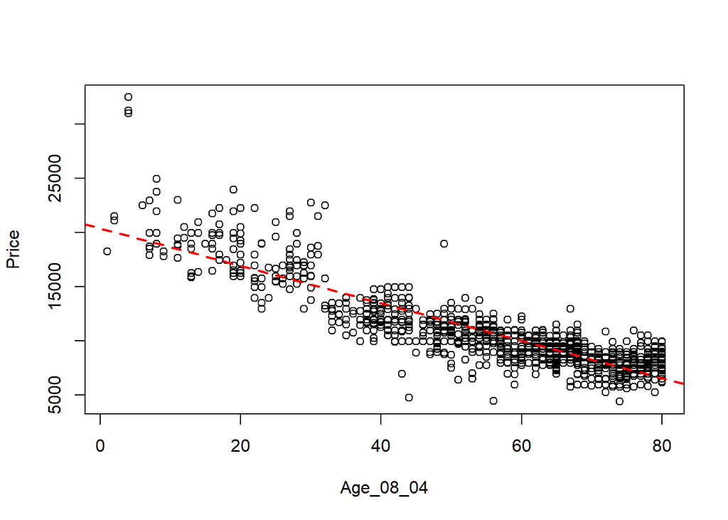

```r
# add the resulting line to the scatter plot
abline(model0, col = "red", lty = 2, lwd = 2)
```

To get more detailed output of the fitted model, we use the summary() function.

```r
sum.model0 <- summary(model0)
sum.model0
```

```
##
## Call:
## lm(formula = Price ~ Age_08_04, data = toyota.train)
##
## Residuals:
##     Min      1Q  Median      3Q     Max
## -8040.1 -1031.5   -40.9   858.2 12798.3
##
## Coefficients:
##              Estimate Std. Error t value Pr(>|t|)
## (Intercept) 20392.856    161.956   125.9   <2e-16 ***
## Age_08_04    -172.791      2.765   -62.5   <2e-16 ***
## ---
## Signif. codes:  0 '***' 0.001 '**' 0.01 '*' 0.05 '.' 0.1 ' ' 1
##
## Residual standard error: 1763 on 1146 degrees of freedom
## Multiple R-squared:  0.7732, Adjusted R-squared:  0.773
## F-statistic:  3906 on 1 and 1146 DF,  p-value: < 2.2e-16
```

What is the resulting regression function?

Note that both of the objects *model0* and *sum.model0* are lists. Therefore, we can extract any components from that list.

```r
model0$coefficients
```

```
## (Intercept)   Age_08_04
##  20392.8564   -172.7908
```

```r
sum.model0$adj.r.squared
```

```
## [1] 0.7729631
```

You may get the confidence intervals for the estimated coefficients. You may recall from your previous stats courses the formula for calculating confidence intervals: $\hat{\beta_j} \pm t_{\alpha / 2, n - p - 1} * SE(\hat{\beta_j})$.

```r
confint(model0)
```

```
##                  2.5 %     97.5 %
## (Intercept) 20075.0924 20710.6204
## Age_08_04    -178.2153  -167.3663
```

### Prediction

To predict *Price* given a new set of records, we use predict().

```r
pred.model0 <- predict(model0, newdata = toyota.valid)
```

Be careful that the argument “newdata” must be a data frame. You can always convert a table, vector, or matrix to a data frame using data.frame().

```r
# Predict Price for Age_08_04 values of 10, 20, and 30
predict(model0, newdata = data.frame(Age_08_04 = c(10, 20, 30)), interval = "confidence")
```

```
##        fit      lwr      upr
## 1 18664.95 18397.98 18931.91
## 2 16937.04 16719.21 17154.87
## 3 15209.13 15037.33 15380.94
```

## Multiple Linear Regression

The following model includes all predictors in the model.

```r
model1 <- lm(Price ~ Age_08_04 + Mfg_Month + KM + Fuel_Type + HP + Met_Color + Color + Automatic +
               CC + Doors + Gears + Quarterly_Tax + Weight + Mfr_Guarantee + BOVAG_Guarantee +
               Guarantee_Period + ABS + Airbag_1 + Airbag_2 + Airco + Automatic_airco +
               Boardcomputer + CD_Player + Central_Lock + Powered_Windows + Power_Steering +
               Radio + Mistlamps + Sport_Model + Backseat_Divider + Metallic_Rim +
               Radio_cassette + Parking_Assistant + Tow_Bar, data = toyota.train)

# more efficient equivalent
model1 <- lm(Price ~ ., data = toyota.train)

# summary
summary(model1)
```

```
##
## Call:
## lm(formula = Price ~ ., data = toyota.train)
##
## Residuals:
##     Min      1Q  Median      3Q     Max
## -5450.2  -597.6   -56.7   623.2  5476.2
##
## Coefficients:
##                     Estimate Std. Error t value Pr(>|t|)
## (Intercept)       -1.159e+03  1.886e+03  -0.615 0.538959
## Age_08_04         -1.137e+02  3.706e+00 -30.676  < 2e-16 ***
## Mfg_Month         -9.112e+01  9.766e+00  -9.331  < 2e-16 ***
## KM                -1.488e-02  1.214e-03 -12.254  < 2e-16 ***
## Fuel_TypeDiesel    3.161e+03  4.965e+02   6.367 2.83e-10 ***
## Fuel_TypePetrol    2.130e+03  3.602e+02   5.914 4.46e-09 ***
## HP                 4.703e+01  5.638e+00   8.342  < 2e-16 ***
## Met_Color         -6.798e+01  7.642e+01  -0.889 0.373929
## ColorBlack         4.203e+02  6.187e+02   0.679 0.497072
## ColorBlue          3.161e+02  6.178e+02   0.512 0.608999
## ColorGreen         4.741e+01  6.194e+02   0.077 0.939007
## ColorGrey          3.738e+02  6.184e+02   0.604 0.545684
## ColorRed           1.875e+02  6.181e+02   0.303 0.761639
## ColorSilver        2.319e+02  6.251e+02   0.371 0.710708
## ColorViolet       -1.031e+02  8.748e+02  -0.118 0.906213
## ColorWhite        -5.631e+02  6.549e+02  -0.860 0.390082
## ColorYellow       -8.803e+01  8.667e+02  -0.102 0.919115
## Automatic          2.404e+02  1.497e+02   1.606 0.108578
## CC                -3.939e+00  5.126e-01  -7.684 3.39e-14 ***
## Doors              1.790e+01  3.935e+01   0.455 0.649237
## Gears             -4.834e+01  1.826e+02  -0.265 0.791318
## Quarterly_Tax      1.307e+01  1.704e+00   7.670 3.76e-14 ***
## Weight             1.550e+01  1.354e+00  11.451  < 2e-16 ***
## Mfr_Guarantee      2.615e+02  6.941e+01   3.768 0.000174 ***
## BOVAG_Guarantee    5.562e+02  1.205e+02   4.617 4.35e-06 ***
## Guarantee_Period   7.442e+01  1.329e+01   5.600 2.70e-08 ***
## ABS               -1.555e+02  1.206e+02  -1.290 0.197409
## Airbag_1           1.307e+02  2.386e+02   0.548 0.583920
## Airbag_2          -1.901e+02  1.230e+02  -1.545 0.122589
## Airco              2.958e+02  8.576e+01   3.449 0.000584 ***
## Automatic_airco    2.000e+03  1.774e+02  11.275  < 2e-16 ***
## Boardcomputer     -2.602e+02  1.111e+02  -2.341 0.019423 *
## CD_Player          1.983e+02  9.445e+01   2.099 0.036020 *
## Central_Lock      -1.304e+02  1.333e+02  -0.978 0.328148
## Powered_Windows    3.534e+02  1.328e+02   2.662 0.007883 **
## Power_Steering     1.762e+02  2.778e+02   0.634 0.525949
## Radio              5.960e+02  7.665e+02   0.778 0.437002
## Mistlamps          6.012e+01  1.056e+02   0.569 0.569171
## Sport_Model        2.245e+02  8.383e+01   2.678 0.007515 **
## Backseat_Divider  -2.331e+02  1.243e+02  -1.875 0.061079 .
## Metallic_Rim       1.359e+02  9.063e+01   1.499 0.134136
## Radio_cassette    -7.061e+02  7.668e+02  -0.921 0.357352
## Parking_Assistant -5.098e+02  6.220e+02  -0.820 0.412653
## Tow_Bar           -1.600e+02  7.587e+01  -2.109 0.035169 *
## ---
## Signif. codes:  0 '***' 0.001 '**' 0.01 '*' 0.05 '.' 0.1 ' ' 1
##
## Residual standard error: 1051 on 1104 degrees of freedom
## Multiple R-squared:  0.9223, Adjusted R-squared:  0.9193
## F-statistic: 304.7 on 43 and 1104 DF,  p-value: < 2.2e-16
```

Are there any insignificant predictors?

```r
# here we manually eliminate some of the insignificant predictors
model2 <- lm(Price ~ . - Power_Steering - Airbag_1 - Airbag_2 - Mistlamps, data = toyota.train)
summary(model2)
```

```
##
## Call:
## lm(formula = Price ~ . - Power_Steering - Airbag_1 - Airbag_2 -
##     Mistlamps, data = toyota.train)
##
## Residuals:
##     Min      1Q  Median      3Q     Max
## -5502.7  -589.0   -62.4   620.9  5597.9
##
## Coefficients:
##                     Estimate Std. Error t value Pr(>|t|)
## (Intercept)       -9.820e+02  1.825e+03  -0.538 0.590627
## Age_08_04         -1.130e+02  3.623e+00 -31.183  < 2e-16 ***
## Mfg_Month         -9.268e+01  9.694e+00  -9.561  < 2e-16 ***
## KM                -1.491e-02  1.213e-03 -12.291  < 2e-16 ***
## Fuel_TypeDiesel    3.158e+03  4.931e+02   6.404 2.23e-10 ***
## Fuel_TypePetrol    2.083e+03  3.580e+02   5.818 7.79e-09 ***
## HP                 4.709e+01  5.576e+00   8.445  < 2e-16 ***
## Met_Color         -6.837e+01  7.593e+01  -0.900 0.368051
## ColorBlack         4.234e+02  6.183e+02   0.685 0.493621
## ColorBlue          3.225e+02  6.175e+02   0.522 0.601593
## ColorGreen         5.135e+01  6.191e+02   0.083 0.933918
## ColorGrey          3.709e+02  6.183e+02   0.600 0.548726
## ColorRed           1.817e+02  6.179e+02   0.294 0.768714
## ColorSilver        2.476e+02  6.247e+02   0.396 0.691977
## ColorViolet       -9.619e+00  8.727e+02  -0.011 0.991208
## ColorWhite        -5.353e+02  6.543e+02  -0.818 0.413467
## ColorYellow       -7.690e+01  8.664e+02  -0.089 0.929292
## Automatic          2.387e+02  1.492e+02   1.600 0.109877
## CC                -3.917e+00  5.102e-01  -7.678 3.54e-14 ***
## Doors              2.113e+01  3.909e+01   0.541 0.588821
## Gears             -4.872e+01  1.802e+02  -0.270 0.786998
## Quarterly_Tax      1.260e+01  1.679e+00   7.508 1.23e-13 ***
## Weight             1.553e+01  1.338e+00  11.607  < 2e-16 ***
## Mfr_Guarantee      2.561e+02  6.923e+01   3.699 0.000227 ***
## BOVAG_Guarantee    5.688e+02  1.197e+02   4.752 2.28e-06 ***
## Guarantee_Period   7.702e+01  1.318e+01   5.843 6.72e-09 ***
## ABS               -2.326e+02  9.463e+01  -2.458 0.014129 *
## Airco              3.002e+02  8.355e+01   3.593 0.000342 ***
## Automatic_airco    2.049e+03  1.657e+02  12.370  < 2e-16 ***
## Boardcomputer     -2.716e+02  1.108e+02  -2.452 0.014345 *
## CD_Player          1.917e+02  9.437e+01   2.031 0.042498 *
## Central_Lock      -1.010e+02  1.317e+02  -0.767 0.443075
## Powered_Windows    3.648e+02  1.320e+02   2.764 0.005804 **
## Radio              7.691e+02  7.526e+02   1.022 0.307045
## Sport_Model        2.101e+02  8.183e+01   2.567 0.010393 *
## Backseat_Divider  -2.526e+02  1.118e+02  -2.260 0.023993 *
## Metallic_Rim       1.474e+02  8.738e+01   1.687 0.091927 .
## Radio_cassette    -8.534e+02  7.539e+02  -1.132 0.257882
## Parking_Assistant -5.047e+02  6.216e+02  -0.812 0.417069
## Tow_Bar           -1.609e+02  7.573e+01  -2.125 0.033798 *
## ---
## Signif. codes:  0 '***' 0.001 '**' 0.01 '*' 0.05 '.' 0.1 ' ' 1
##
## Residual standard error: 1051 on 1108 degrees of freedom
## Multiple R-squared:  0.922,  Adjusted R-squared:  0.9193
## F-statistic: 335.9 on 39 and 1108 DF,  p-value: < 2.2e-16
```

# Model Assessment

We now need to evaluate the model’s performance using a variety of metrics.

Commonly used metrics include **MSE**, **adjusted R<sup>2</sup>**, **AIC**, and **BIC** for in-sample performance; and **RMSE** and **ME** for out-of-sample performance.

## In-sample Performance

```r
sum.model1 <- summary(model1)

# MSE
(sum.model1$sigma)^2
```

```
## [1] 1105259
```

```r
# R-squared
sum.model1$r.squared
```

```
## [1] 0.9222926
```

```r
# adjusted R-squared
sum.model1$adj.r.squared
```

```
## [1] 0.919266
```

AIC and BIC of the model are the information criteria. Smaller values indicate a better fit.

```r
AIC(model1)
```

```
## [1] 19278.11
```

```r
BIC(model1)
```

```
## [1] 19505.17
```

AIC, BIC, and adjusted *R<sup>2</sup>* include a complexity penalty in their calculations. When comparing across different models, they are better indicators of how well the model will perform on future data.

## Out-of-sample Prediction (Validation Error)

We’ll compare the predictive performance of model0, model1, and model2 using the validation dataset.

```r
library(forecast)
pred.model0 <- predict(model0, newdata = toyota.valid)
pred.model1 <- predict(model1, newdata = toyota.valid)
pred.model2 <- predict(model2, newdata = toyota.valid)

accuracy(pred.model0, toyota.valid$Price)
```

```
##                ME     RMSE      MAE       MPE     MAPE
## Test set 15.52419 1672.988 1204.125 -1.537892 12.21493
```

```r
accuracy(pred.model1, toyota.valid$Price)
```

```
##                ME     RMSE      MAE        MPE     MAPE
## Test set 29.46322 1226.968 838.9063 -0.6352704 8.423559
```

```r
accuracy(pred.model2, toyota.valid$Price)
```

```
##               ME     RMSE      MAE        MPE     MAPE
## Test set 28.7672 1218.469 836.3854 -0.6447808 8.390795
```

Given the choice of these three models, which one would you choose for predicting future prices?

# Variable Selection

Here we introduce different techniques of variable selection for linear regression. Note that these methods are not limited to linear regression. We will revisit them in future lectures and labs.

## Compare Model Fit Manually

You can certainly create and compare subset models manually as we did above.

```r
sum0 <- summary(model0)
sum1 <- summary(model1)
sum2 <- summary(model2)

AIC(model0); BIC(model0); sum0$adj.r.squared
```

```
## [1] 20423.96
```

```
## [1] 20439.09
```

```
## [1] 0.7729631
```

```r
AIC(model1); BIC(model1); sum1$adj.r.squared
```

```
## [1] 19278.11
```

```
## [1] 19505.17
```

```
## [1] 0.919266
```

```r
AIC(model2); BIC(model2); sum2$adj.r.squared
```

```
## [1] 19274.13
```

```
## [1] 19481.01
```

```
## [1] 0.9192753
```

## Exhaustive Search (Best Subsets)

The “leaps” package provides the procedures for exhaustive search.

```r
install.packages("leaps") # this only needs done once
```

```r
library(leaps)
```

Before performing exhaustive search, you must first create binary dummy variables for your categorical predictors.

```r
dummies <- as.data.frame(model.matrix(~ 0 + Fuel_Type + Color, data = toyota))
t(t(names(dummies)))
```

```
##       [,1]
##  [1,] "Fuel_TypeCNG"
##  [2,] "Fuel_TypeDiesel"
##  [3,] "Fuel_TypePetrol"
##  [4,] "ColorBlack"
##  [5,] "ColorBlue"
##  [6,] "ColorGreen"
##  [7,] "ColorGrey"
##  [8,] "ColorRed"
##  [9,] "ColorSilver"
## [10,] "ColorViolet"
## [11,] "ColorWhite"
## [12,] "ColorYellow"
```

```r
toyota <- cbind(toyota[, -c(5,8)], dummies[ , -c(1,4)])
t(t(names(toyota)))
```

```
##       [,1]
##  [1,] "Price"
##  [2,] "Age_08_04"
##  [3,] "Mfg_Month"
##  [4,] "KM"
##  [5,] "HP"
##  [6,] "Met_Color"
##  [7,] "Automatic"
##  [8,] "CC"
##  [9,] "Doors"
## [10,] "Gears"
## [11,] "Quarterly_Tax"
## [12,] "Weight"
## [13,] "Mfr_Guarantee"
## [14,] "BOVAG_Guarantee"
```

[output cut: 29 more lines]

Then you’ll need to redefine your training and validation sets to include these dummy variables. (This is why, although R’s lm() function creates binary dummy variables automomatically, it may be worthwhile to always create them up front regardless.)

```r
set.seed(1)
train.rows <- sample(nrow(toyota), nrow(toyota) * 0.8)
toyota.train <- toyota[train.rows, ]
toyota.valid <- toyota[-train.rows, ]
```

Which subset of variables should you include in order to minimize Cp?

```r
# regsubsets will only accept a data frame as an input
toyota.search <- regsubsets(Price ~ ., data = toyota.train, nbest = 1, nvmax = ncol(toyota.train))
sum <- summary(toyota.search)
sum$which # be sure you understand how to interpret this output
```

```
##    (Intercept) Age_08_04 Mfg_Month    KM    HP Met_Color Automatic    CC
## 1         TRUE      TRUE     FALSE FALSE FALSE     FALSE     FALSE FALSE
## 2         TRUE      TRUE     FALSE FALSE FALSE     FALSE     FALSE FALSE
## 3         TRUE      TRUE     FALSE  TRUE FALSE     FALSE     FALSE FALSE
## 4         TRUE      TRUE     FALSE  TRUE FALSE     FALSE     FALSE FALSE
## 5         TRUE      TRUE     FALSE  TRUE  TRUE     FALSE     FALSE FALSE
## 6         TRUE      TRUE      TRUE  TRUE  TRUE     FALSE     FALSE FALSE
## 7         TRUE      TRUE      TRUE  TRUE FALSE     FALSE     FALSE FALSE
## 8         TRUE      TRUE      TRUE  TRUE FALSE     FALSE     FALSE FALSE
## 9         TRUE      TRUE      TRUE  TRUE FALSE     FALSE     FALSE FALSE
## 10        TRUE      TRUE      TRUE  TRUE FALSE     FALSE     FALSE FALSE
## 11        TRUE      TRUE      TRUE  TRUE  TRUE     FALSE     FALSE  TRUE
## 12        TRUE      TRUE      TRUE  TRUE  TRUE     FALSE     FALSE  TRUE
## 13        TRUE      TRUE      TRUE  TRUE  TRUE     FALSE     FALSE  TRUE
## 14        TRUE      TRUE      TRUE  TRUE  TRUE     FALSE     FALSE  TRUE
```

[output cut: 329 more lines]

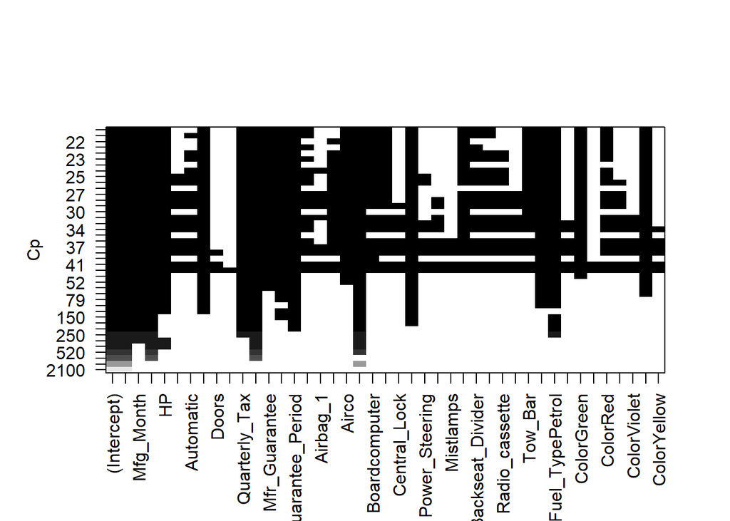

```r
# a useful visualization of the models returned by exhaustive search
par(mfrow = c(1, 1))
plot(toyota.search, scale = "Cp")
```

Each row in the plot represents a model. Black indicates that the variable is included in the model, while white indicates it is not. The possible values of scale are “Cp”, “adjr2”, “r2”, or “bic”.

How many predictors are in the best model based on Cp?

```r
t(t(sum$cp))
```

```
##             [,1]
##  [1,] 2080.30507
##  [2,] 1297.94885
##  [3,]  842.60603
##  [4,]  524.81130
##  [5,]  411.99760
##  [6,]  308.15235
##  [7,]  252.55657
##  [8,]  208.86346
##  [9,]  176.78522
## [10,]  153.68861
## [11,]  123.82553
## [12,]  105.21634
## [13,]   78.77929
## [14,]   68.36167
```

[output cut: 28 more lines]

## Forward/Backward/Stepwise Regression Using AIC

To perform forward, backward, and stepwise regression in R, we need to first define starting points.

```r
toyota.null <- lm(Price ~ 1, data = toyota.train)
toyota.full <- lm(Price ~ ., data = toyota.train)
```

“toyota.null” is the model with no predictors in it, while “toyota.full” is the full model containing all predictors.

### Forward Selection

```r
toyota.fwd <- step(toyota.null, scope = list(lower = toyota.null, upper = toyota.full),
                    direction = "forward")
```

```
## Start:  AIC=18865.15
## Price ~ 1
##
##                     Df  Sum of Sq        RSS   AIC
## + Age_08_04          1 1.2141e+10 3.5620e+09 17164
## + Weight             1 5.9369e+09 9.7657e+09 18322
## + Boardcomputer      1 5.8184e+09 9.8842e+09 18336
## + Automatic_airco    1 5.5199e+09 1.0183e+10 18370
## + KM                 1 5.3228e+09 1.0380e+10 18392
## + CD_Player          1 4.0730e+09 1.1630e+10 18522
## + Airco              1 3.0091e+09 1.2694e+10 18623
## + Powered_Windows    1 2.0867e+09 1.3616e+10 18704
## + Central_Lock       1 2.0238e+09 1.3679e+10 18709
## + ABS                1 1.4748e+09 1.4228e+10 18754
## + HP                 1 1.4500e+09 1.4253e+10 18756
## + Airbag_2           1 1.0279e+09 1.4675e+10 18789
## + Quarterly_Tax      1 9.8855e+08 1.4714e+10 18793
## + Mistlamps          1 7.2059e+08 1.4982e+10 18813
## + Mfr_Guarantee      1 5.8368e+08 1.5119e+10 18824
## + Doors              1 5.6974e+08 1.5133e+10 18825
## + CC                 1 5.1618e+08 1.5186e+10 18829
## + ColorGrey          1 4.3701e+08 1.5266e+10 18835
## + Sport_Model        1 4.0993e+08 1.5293e+10 18837
## + Tow_Bar            1 3.9527e+08 1.5307e+10 18838
## + Guarantee_Period   1 2.3673e+08 1.5466e+10 18850
## + Met_Color          1 2.2000e+08 1.5483e+10 18851
## + ColorGreen         1 1.9046e+08 1.5512e+10 18853
## + ColorWhite         1 1.8027e+08 1.5522e+10 18854
## + Backseat_Divider   1 1.7948e+08 1.5523e+10 18854
## + ColorRed           1 1.7502e+08 1.5528e+10 18854
## + Airbag_1           1 1.4755e+08 1.5555e+10 18856
## + Metallic_Rim       1 1.1431e+08 1.5588e+10 18859
## + Fuel_TypeDiesel    1 1.1350e+08 1.5589e+10 18859
## + Fuel_TypePetrol    1 8.2199e+07 1.5620e+10 18861
## + Power_Steering     1 7.7084e+07 1.5625e+10 18862
## + Radio_cassette     1 6.1926e+07 1.5641e+10 18863
## + Radio              1 6.0628e+07 1.5642e+10 18863
## + Parking_Assistant  1 4.3644e+07 1.5659e+10 18864
## <none>                            1.5703e+10 18865
## + ColorSilver        1 2.7225e+07 1.5675e+10 18865
```

[output cut: 919 more lines]

```
## + Met_Color          1   1478543 1233599480 15997
## + Airbag_2           1   1363861 1233714162 15997
## + Radio              1   1339573 1233738450 15997
## + Power_Steering     1   1195182 1233882841 15997
## + Airbag_1           1    995679 1234082345 15997
## + ColorSilver        1    767240 1234310783 15997
## + Parking_Assistant  1    672989 1234405034 15998
## + ColorYellow        1    487923 1234590100 15998
## + Central_Lock       1    460236 1234617787 15998
## + ColorViolet        1    366610 1234711413 15998
## + Mistlamps          1    251469 1234826554 15998
## + ColorGrey          1    221529 1234856494 15998
## + Gears              1    157263 1234920760 15998
## + ColorBlue          1    137935 1234940088 15998
## + Doors              1     45680 1235032343 15998
```

```r
# For each of these algorithms, it's important to look through the output and understand how
# the algorithm determines which step to take next to improve the model.
summary(toyota.fwd)
```

```
##
## Call:
## lm(formula = Price ~ Age_08_04 + Automatic_airco + Weight + KM +
##     HP + Mfg_Month + CC + Quarterly_Tax + Powered_Windows + Guarantee_Period +
##     BOVAG_Guarantee + Fuel_TypeDiesel + Fuel_TypePetrol + ColorWhite +
##     Mfr_Guarantee + Airco + ColorGreen + Boardcomputer + Tow_Bar +
##     ABS + CD_Player + Sport_Model + Backseat_Divider + ColorRed +
##     Metallic_Rim, data = toyota.train)
##
## Residuals:
##     Min      1Q  Median      3Q     Max
## -5850.6  -613.2   -58.8   613.2  5478.4
##
## Coefficients:
##                    Estimate Std. Error t value Pr(>|t|)
## (Intercept)      -1.776e+03  1.339e+03  -1.326 0.185022
## Age_08_04        -1.114e+02  3.540e+00 -31.471  < 2e-16 ***
## Automatic_airco   2.073e+03  1.636e+02  12.669  < 2e-16 ***
## Weight            1.637e+01  1.183e+00  13.836  < 2e-16 ***
## KM               -1.497e-02  1.194e-03 -12.536  < 2e-16 ***
## HP                4.465e+01  5.291e+00   8.437  < 2e-16 ***
## Mfg_Month        -9.149e+01  9.589e+00  -9.541  < 2e-16 ***
## CC               -3.801e+00  4.971e-01  -7.646 4.45e-14 ***
## Quarterly_Tax     1.267e+01  1.656e+00   7.654 4.18e-14 ***
## Powered_Windows   2.717e+02  7.898e+01   3.440 0.000602 ***
## Guarantee_Period  7.557e+01  1.297e+01   5.827 7.37e-09 ***
## BOVAG_Guarantee   5.674e+02  1.180e+02   4.807 1.74e-06 ***
## Fuel_TypeDiesel   2.947e+03  4.689e+02   6.285 4.68e-10 ***
## Fuel_TypePetrol   2.084e+03  3.505e+02   5.947 3.64e-09 ***
## ColorWhite       -8.458e+02  2.216e+02  -3.817 0.000143 ***
## Mfr_Guarantee     2.459e+02  6.815e+01   3.609 0.000321 ***
## Airco             2.936e+02  8.194e+01   3.583 0.000354 ***
## ColorGreen       -2.789e+02  9.135e+01  -3.054 0.002314 **
## Boardcomputer    -2.595e+02  1.092e+02  -2.376 0.017671 *
## Tow_Bar          -1.829e+02  7.311e+01  -2.501 0.012509 *
## ABS              -2.279e+02  9.338e+01  -2.441 0.014815 *
## CD_Player         2.091e+02  9.123e+01   2.292 0.022112 *
## Sport_Model       2.063e+02  7.832e+01   2.634 0.008566 **
## Backseat_Divider -2.277e+02  1.098e+02  -2.075 0.038220 *
## ColorRed         -1.398e+02  8.266e+01  -1.691 0.091087 .
## Metallic_Rim      1.227e+02  8.371e+01   1.466 0.142968
## ---
## Signif. codes:  0 '***' 0.001 '**' 0.01 '*' 0.05 '.' 0.1 ' ' 1
##
## Residual standard error: 1049 on 1122 degrees of freedom
## Multiple R-squared:  0.9213, Adjusted R-squared:  0.9196
## F-statistic: 525.7 on 25 and 1122 DF,  p-value: < 2.2e-16
```

### Backward Elimination (Output omitted here)

```r
toyota.back <- step(toyota.full, direction = "backward")
summary(toyota.back)
```

### Stepwise Regression (Output omitted here)

```r
toyota.step <- step(toyota.null, scope = list(lower = toyota.null, upper = toyota.full),
                     direction = "both")
summary(toyota.step)
```

Compare the performance of the model(s) created from these algorithms to model0, model1, and model2 created above. Which model would likely be best for predicting new prices?

It is a good idea to record the results of your models in a table to facilitate comparison and share the results of the various models. I don’t know of a simple way to do this in R, so I just record my results in Excel. (If you find a more elegant way to do this in R, please share.)

[figure not shown]

Table of Results

# Reducing Categories

Often, when a factor (categorical variable) has a large number of levels (categories), it is often desirable to reduce the number of categories by combining some based on some criteria. You might combine similar categories or combine categories with relatively few records into a single category.

```r
# here we'll combine the rarer colors into an "Other" category

# we'll first need to read the dataset in again since we've already created the dummies above
toyota <- read.csv("ToyotaCorolla.csv")

# see how frequently each color occurs
colorfreq <- data.frame(table(toyota$Color))
colorfreq[order(colorfreq$Freq, decreasing = TRUE),]
```

```
##      Var1 Freq
## 5    Grey  301
## 3    Blue  283
## 6     Red  278
## 4   Green  220
## 2   Black  191
## 7  Silver  122
## 9   White   31
## 8  Violet    4
## 1   Beige    3
## 10 Yellow    3
```

```r
# list the colors that appear in at least 5% of the records (this is not a rule of thumb - just the
# cutoff I chose here)
common <- colorfreq[colorfreq$Freq / nrow(toyota) > .05, ]
common
```

```
##     Var1 Freq
## 2  Black  191
## 3   Blue  283
## 4  Green  220
## 5   Grey  301
## 6    Red  278
## 7 Silver  122
```

```r
# create a new factor color2 that combines all other colors into an "Other" level
toyota$color2 <- as.factor(ifelse(toyota$Color %in% c("Black", "Blue", "Green", "Grey", "Red",
                                                      "Silver"),
                                     as.character(toyota$Color), "Other"))
toyota[1:20, "color2"]
```

```
##  [1] Blue   Silver Blue   Black  Black  Other  Grey   Grey   Red    Blue
## [11] Silver Red    Red    Black  Grey   Grey   Grey   Blue   Grey   Grey
## Levels: Black Blue Green Grey Other Red Silver
```

You could have simply redefined the *color* variable instead of creating the new *color2* variable, but then you would have to determine how to handle the now-unused factor levels when creating dummies.

# Summary

From this lab, you should now be able to use basic functions to conduct linear regression analysis. The training and validation sets are always crucial for any supervised data mining analysis. You should focus more on the validation error than the training error, as the goal is to accurately predict new outcomes. You also studied various variable selection techniques for linear regression. These techniques are especially important when the number of predictors is large.

# Exercise

- Re-run the full model using the *color2* variable instead of *Color*.
  - How did this change affect the model?
- Find some good reduced models using the *color2* variable instead of *Color*. How does this affect the variable selection.
- Revisit the Boston Housing data. Conduct linear regression analysis using both the full model and various variable selection algorithms in order to find a good model for predicting median home values (MEDV) on new census tracts.